# PRESENTATION FOR MINI PROJECT (EDA) slides

## Exploratory data analysis(Mini - project)

### Project work flow :

### Step 1: Data Import & Preparation

Imported raw data from CSV into a Pandas DataFrame.

### Step 2: Duration Calculation

Calculated the duration (study time) by subtracting the start time from the end time for each entry.

### Step 3: Analyzing Relationships

Analyzed the relationship between: Rate per exhaustion (RPE) and Name. Name and Duration. Subject and Duration.

### Step 4: Data Segmentation

Curated separate DataFrames for each of the 3 girls to focus on individual data.

#### Compared:

Average duration. Average RPE for each girl.

### Step 5: Individual Analysis

Calculated the same relationships (subject-duration, subject-RPE) for each girl individually, resulting in 6 different DataFrames (3 girls × 2 relationships).

### Step 6: Visualization – Combined Bar Graph

#### Plotted a combined graph with:

Names on the X-axis. Joint bars representing different subjects. Y-axis showing the study duration for each girl.

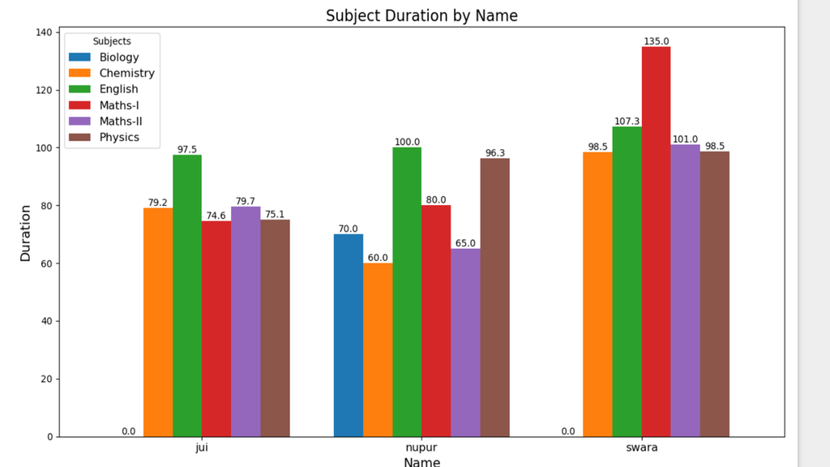

### Step 7: Time Slot Analysis

Analyzed when each girl studied (dawn, morning, afternoon, evening) to estimate efficiency and working time.

Plotted combined graph for time slots and study duration.

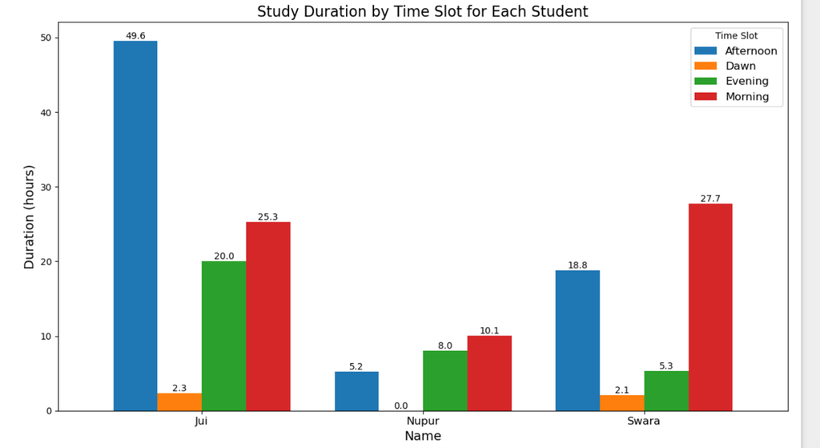

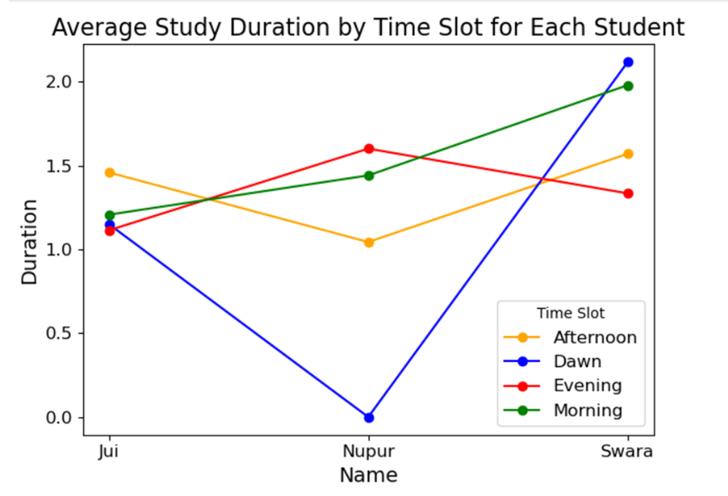

### Step 8: Visualizing Max Duration & RPE

#### Plotted individual graphs showing:

Max study duration. Rate of Perceived Exhaustion (RPE). Actual duration Actual RPE

### Nupur :

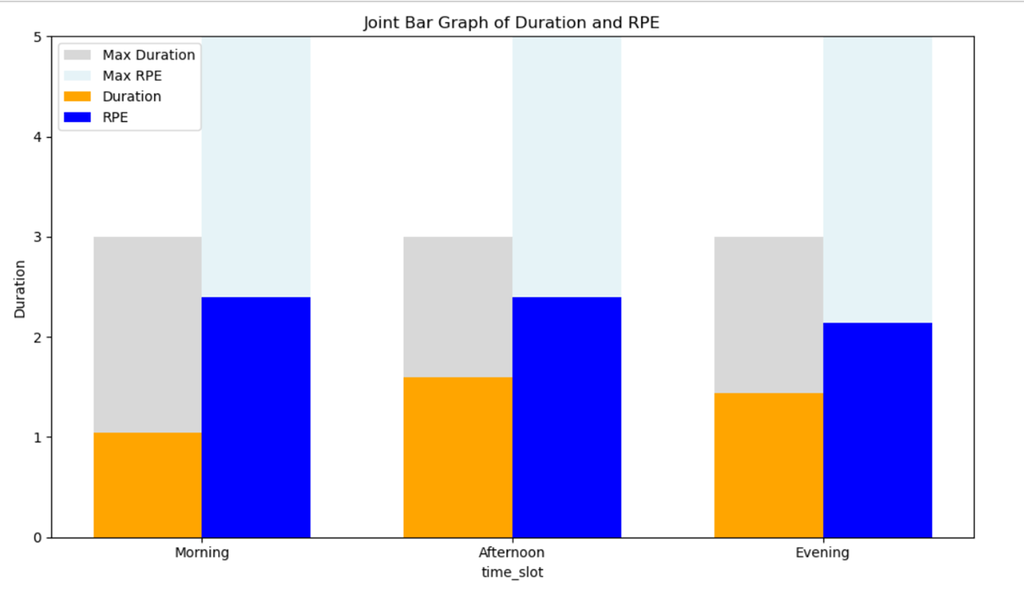

### Swara :

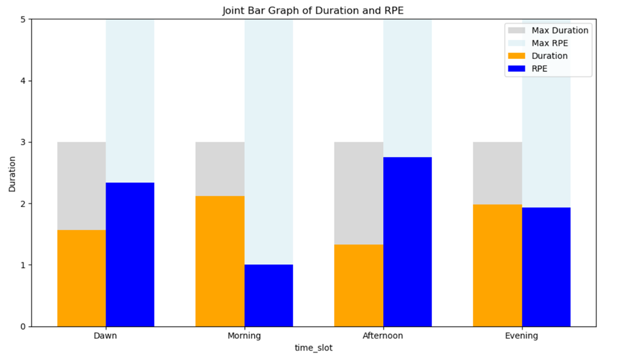

### Jui :

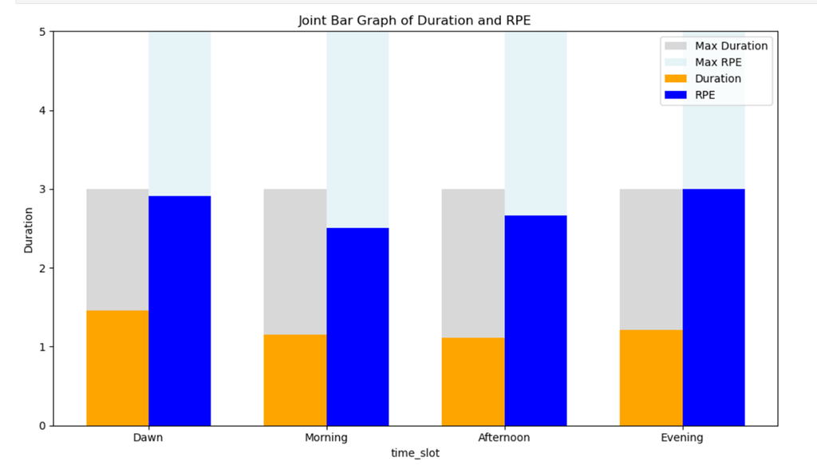

### Step 9: No. of Sessions & Comparison

Analyzed the number of sessions logged by each girl.

#### Compared:

Average duration. Average RPE for each girl.

### Step 10: Combined Analysis

Conducted a combined analysis to compare overall results for the 3 girls.

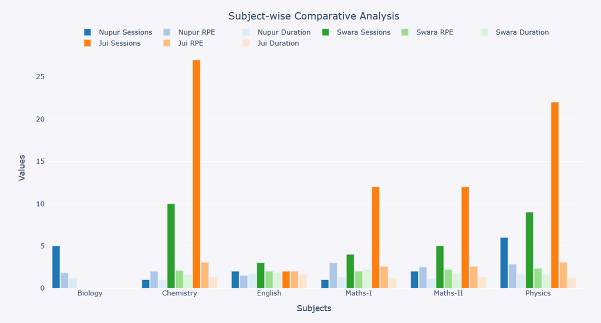

#### Figured out the relation between RPE no. of sessions attended and no. of hours logged in for every subject

#### Ultimately : Efficiency observation